# Отчет по лабораторной работе "Поиск 1- и 2-мостов в графах"

### Выполнила Кладиева Алина, группа 18ИАД

#### Репозиторий с исходным кодом: https://github.com/akladiev/bridges

В рамках лабораторной работы реализовано три алгоритма на языке Python 3: детерминированный поиск 1-мостов (det_1 на графиках); рандомизированный поиск 1-мостов (rand_1); и рандомизированный поиск 2-мостов (rand_2). Исходный код алгоритмов можно найти в файле *find_bridges.py*

Для сортировки ребер в рандомизированном алгоритме поиска 2-мостов было рассмотрено три варианта: стандартная сортировка языка Python (sorted, реализация алгоритма Timsort); и две сортировки, реализованные вручную: карманная (bucket) и поразрядная (radix). Исходный код сортировок - в файле *sorting.py*

Для генерации графов был реализован простой алгоритм, принимающий на вход число вершин и вероятность проведения ребра между каждой парой вершин (исходный код - *generate_graph.py*, функция *generate*)

Для проверки результатов были написаны юнит-тесты (см. подпапку *tests*). Тесты покрывают генерацию графа, корректность работы алгоритмов поиска мостов и сортировки. Команда для запуска тестов (из корневой директории репозитория): *python -m unittest discover -s tests*

Тестовые данные для проверки алгоритмов поиска мостов находятся в *tests/tests_data*. Каждый тестовый граф сериализован в файл с расширением *.graph* в виде списка смежности. Информация о каждом графе (число вершин и реальное число мостов) сохранена в yaml-файле с именем, аналогичным имени соответствующего *.graph*-файла. Референсные данные о реальном числе мостов в графе были собраны при помощи библиотеки Networkx.

Для оценки производительности было измерено время запуска разных алгоритмов поиска мостов на пяти разреженных графах (плотность от 0.001% до 0.1% от максимального числа ребер) и пяти плотных графах (плотность от 0.9% до 0.999%). Для рандомизированных алгоритмов время рассчитывалось как среднее время выполнения от трех запусков. Команда для запуска бенчмарка: *python benchmark.py*. Результаты представлены на графиках ниже.

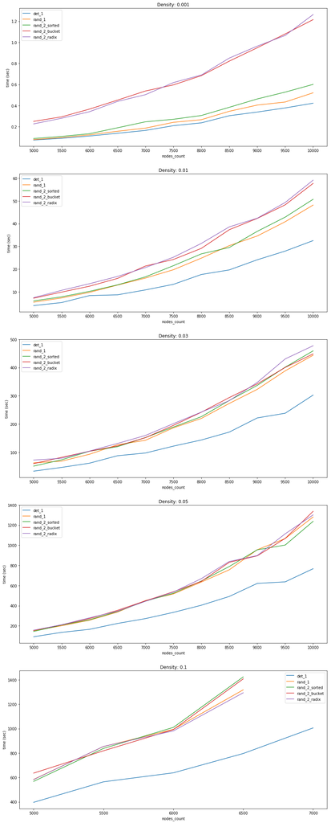

```python
from utils import plot_benchmark_data
data = plot_benchmark_data("bench_data_sparse.json")
```

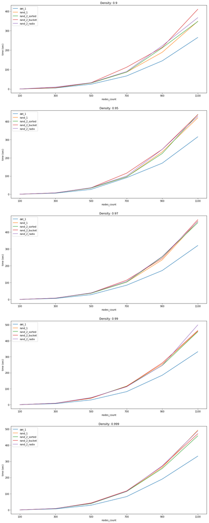

```python
from utils import plot_benchmark_data
data = plot_benchmark_data("bench_data_dense.json")
```

Как можно видеть, детерминированный алгоритм существенно выигрывает по времени выполнения в сравнении с рандомизированными. Кроме того, для детерминированного алгоритма затраченное время с увеличением количества вершин в графе растет слегка медленнее.

Что касается сортировок в алгоритме поиска 2-мостов: можно видеть, что в целом стандартная сортировка Timsort ожидаемо выигрывает у сортировок, реализованных вручную. Поразрядная и карманная сортировки же в целом одинаково влияют на скорость работы алгоритма, однако, возможно, требуется больше запусков для получения более надежного результата.